# MGT 6203 - Final report - Multiple Linear regression models

# We will transform the response variable and evaluate the new model to identify if the transformation is useful. but first we will use box cox to determine the optimal lambda

```r
#library(MASS)
#bc < boxcox(model2)
#bc
#lambda <- bc$x[which(bc$y==max(bc$y))]
#lambda
#[1] 0.3434343
```

```r
model3 <- lm(sqrt(Amount)~Airline + Time + arr_flights_sum + arr_del15_sum +
    carrier_ct_sum + weather_ct_sum + nas_ct_sum + security_ct_sum +
    late_aircraft_ct_sum + arr_cancelled_sum + arr_diverted_sum +
    arr_delay_sum + carrier_delay_sum + weather_delay_sum + nas_delay_sum +
    security_delay_sum , combined_qts, na.action = na.exclude)
summary(model3)
```

```
##
## Call:
## lm(formula = sqrt(Amount) ~ Airline + Time + arr_flights_sum +
##     arr_del15_sum + carrier_ct_sum + weather_ct_sum + nas_ct_sum +
##     security_ct_sum + late_aircraft_ct_sum + arr_cancelled_sum +
##     arr_diverted_sum + arr_delay_sum + carrier_delay_sum + weather_delay_sum +
##     nas_delay_sum + security_delay_sum, data = combined_qts,
##     na.action = na.exclude)
##
## Residuals:
##     Min      1Q  Median      3Q     Max
## -4.5594 -1.6100  0.4457  1.5071  4.4384
##
## Coefficients:
##                        Estimate Std. Error t value Pr(>|t|)
## (Intercept)           1.187e+02  1.589e+01   7.467 1.37e-07 ***
## AirlineSouthwest      5.423e+01  1.218e+01   4.454 0.000182 ***
## AirlineUnited         8.820e+00  3.909e+00   2.257 0.033842 *
## Time20172             6.119e+00  3.898e+00   1.570 0.130183
## Time20173             1.175e+01  4.063e+00   2.891 0.008239 **
## Time20174             9.249e+00  3.421e+00   2.703 0.012679 *
## Time20181             6.124e+00  3.008e+00   2.036 0.053462 .
## Time20182             1.384e+01  4.077e+00   3.394 0.002493 **
## Time20183             1.136e+01  6.642e+00   1.710 0.100750
## Time20184             1.764e+01  3.839e+00   4.594 0.000128 ***
## Time20191             8.706e+00  3.745e+00   2.325 0.029265 *
## Time20192             1.094e+01  5.745e+00   1.904 0.069461 .
## Time20193             9.755e+00  5.734e+00   1.701 0.102351
## Time20194             1.547e+01  3.990e+00   3.877 0.000762 ***
## Time20201             8.965e+00  7.357e+00   1.219 0.235375
## Time20202            -7.978e+01  1.235e+01  -6.460 1.36e-06 ***
## Time20203            -6.812e+01  9.576e+00  -7.114 3.02e-07 ***
## Time20204            -5.717e+01  7.369e+00  -7.758 7.24e-08 ***
## Time20211            -5.064e+01  8.185e+00  -6.187 2.60e-06 ***
## Time20212            -2.485e+01  4.917e+00  -5.054 4.08e-05 ***
## Time20213            -7.510e-01  4.541e+00  -0.165 0.870095
## Time20214             4.560e+00  5.364e+00   0.850 0.404002
## Time20221            -3.664e+00  5.167e+00  -0.709 0.485373
## Time20222             1.403e+01  4.612e+00   3.042 0.005791 **
## Time20223            -2.997e+00  5.506e+00  -0.544 0.591472
## arr_flights_sum      -3.738e-04  7.982e-05  -4.683 0.000103 ***
## arr_del15_sum        -5.279e+00  8.732e+00  -0.605 0.551349
## carrier_ct_sum        5.277e+00  8.731e+00   0.604 0.551474
## weather_ct_sum        5.266e+00  8.731e+00   0.603 0.552297
## nas_ct_sum            5.276e+00  8.732e+00   0.604 0.551607
## security_ct_sum       5.169e+00  8.756e+00   0.590 0.560746
## late_aircraft_ct_sum  5.280e+00  8.732e+00   0.605 0.551260
## arr_cancelled_sum    -9.062e-04  4.362e-04  -2.078 0.049095 *
## arr_diverted_sum      3.527e-02  1.412e-02   2.498 0.020100 *
## arr_delay_sum        -9.505e-06  1.434e-05  -0.663 0.513898
## carrier_delay_sum     2.840e-05  2.234e-05   1.271 0.216311
## weather_delay_sum     6.138e-05  6.225e-05   0.986 0.334393
## nas_delay_sum         6.482e-05  3.546e-05   1.828 0.080562 .
## security_delay_sum    8.376e-04  7.055e-04   1.187 0.247235
## ---
## Signif. codes:  0 '***' 0.001 '**' 0.01 '*' 0.05 '.' 0.1 ' ' 1
##
## Residual standard error: 3.254 on 23 degrees of freedom
##   (6 observations deleted due to missingness)
## Multiple R-squared:  0.9894, Adjusted R-squared:  0.972
## F-statistic: 56.73 on 38 and 23 DF,  p-value: 8.61e-16
```

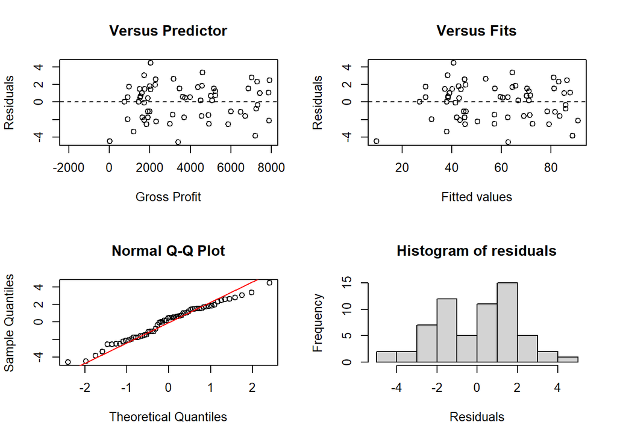

```r
par(mfrow=c(2,2))
plot(combined_qts$Amount, residuals(model3),xlab="Gross Profit",ylab="Residuals", main="Versus Predictor")
abline(h=0,lty=2)

plot(fitted(model3),residuals(model3),xlab="Fitted values",ylab="Residuals",main="Versus Fits")
abline(h=0,lty=2)

qqnorm(residuals(model3))
qqline(residuals(model3),col="red")
hist(residuals(model3),main="Histogram of residuals",xlab="Residuals")
```

# The transformation has definitively improved the 3rd model. However we can see that the Normality assumption is still violated.

# The implication of the Normality assumption violation is that the uncertainly in predicting the Gross Profit would be higher than estimated using this model.

# The model might not contain as many significant factors to accurately predict Gross Profit.

# Thus we conclude that weather delays alone does not statistically affect airlines Gross Profit